# Predicting IMBD Scores

Shivani Dedhia, Akhila Pamukuntla, Nafis Chowdhury, Akshita Jain

## STA 9750 Final Project

## Introduction

Many factors such as user reviews, budget of the movie, actor’s and director’s popularity etc play role in making a movie successful. IMDB is the world’s most popular database designed to help people learn more about movies, TV shows, etc. IMDB plays an important role in measuring the success of a movie by providing ratings considering various factors. This project focuses on which factor has the most impact on the IMDB score of a movie.

We fetched our data from IMDB 5000 movie dataset (https://www.kaggle.com/suchitgupta60/IMDB-data), which consists of 5043 movies across 100 years from 66 countries. The data consists 28 variables such as Director, Actors, Duration, Gross, Budget, Genres, Facebook Likes, etc.

We will be using modeling techniques along with visualizations to identify the most important variable that impacts the success and rating of a movie.

## Data Exploration

After cleaning the data, we narrowed our scope of model to 26 variables and 3806 rows. We removed aspect ratio, IMDB movie link and color as they were redundant to our analysis. We also calculated net profit and return on investment (ROI) of all the movies. Further to simplify our data we bifurcated the countries in three categories, USA, UK and Others. We modified content rating to reflect modern rating system.

IMDB offers a grading scale that allows users to rate films on a scale of one to ten. Submitted ratings are filtered and weighted in various ways to produce a mean.

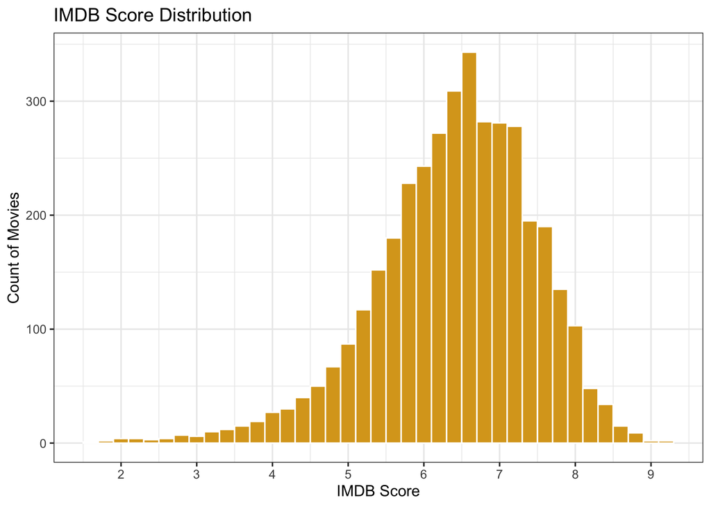

The table below is filtered by IMDB score greater than 7.5 and arranged in descending order. The majority of the movies have an IMDB score of 7.6. As the IMDB score increases above 8.8, the number of movies drop to less than 5. Only 0.21% of the movies are rated above 8.8 which we can also see in the histogram shown above.

```
## # A tibble: 17 x 2
## # Groups:   imdb_score [17]
##    imdb_score     n
##         <dbl> <int>
##  1        7.6   100
##  2        7.7    90
##  3        7.8    83
##  4        8      55
##  5        7.9    52
##  6        8.1    48
##  7        8.2    24
##  8        8.3    24
##  9        8.5    19
## 10        8.4    15
## 11        8.6     8
## 12        8.7     7
## 13        8.8     5
## 14        8.9     4
## 15        9       2
## 16        9.2     1
## 17        9.3     1
```

## Impact of Content Rating on IMDB Score

The average IMDB score is 6 which is considered as a poor score. The content rating with the ‘R’ category has the highest count of 1809 movies which may be the reason that ‘R’ has the highest IMDB rating compared to others. However, PG-13 has the second highest count of 1314 movies with an average IMDB score of less than 6.3. As per this distribution we conclude that content rating does not show a strong impact on the IMDB score of a movie.

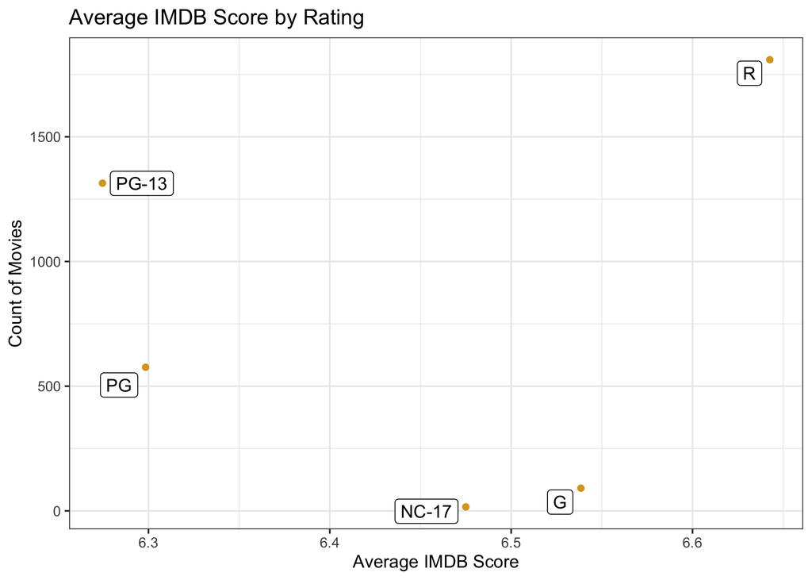

## Distribution of Directors and their Effect on the IMDB Score

We grouped the directors here by the number of movies they directed. Further, we filtered the data to show only directors with movies directed above 10 and below 50 to remove any anomalies in the data. Directors with more movies could have a higher fan following, credibility and success rate possibly leading to a higher IMDB score.

According to the distribution shown below, even after filtering, the number of movies for most of the directors are between 10 to 15, few are in the range of 15 to 20 and rest of the two are outliers.

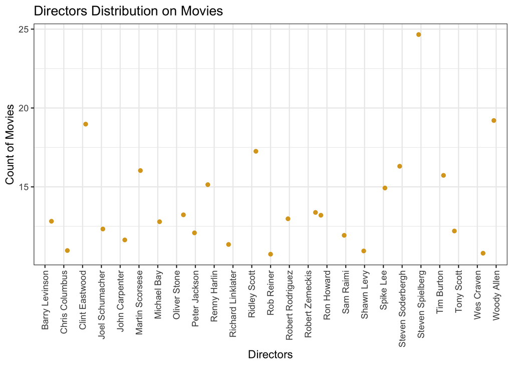

The chart below shows the average IMDB score for directors with 15 or more movies directed. Only a few directors have movies directed above 15 in this data set. The IMDB score is above 5.5 for directors with more than 15 movies. Steven Spielberg is the only director to direct ~ 24 movies. Most of the directors here have received a higher IMDB score which shows that the number of movies directed has a slight impact on the IMDB score.

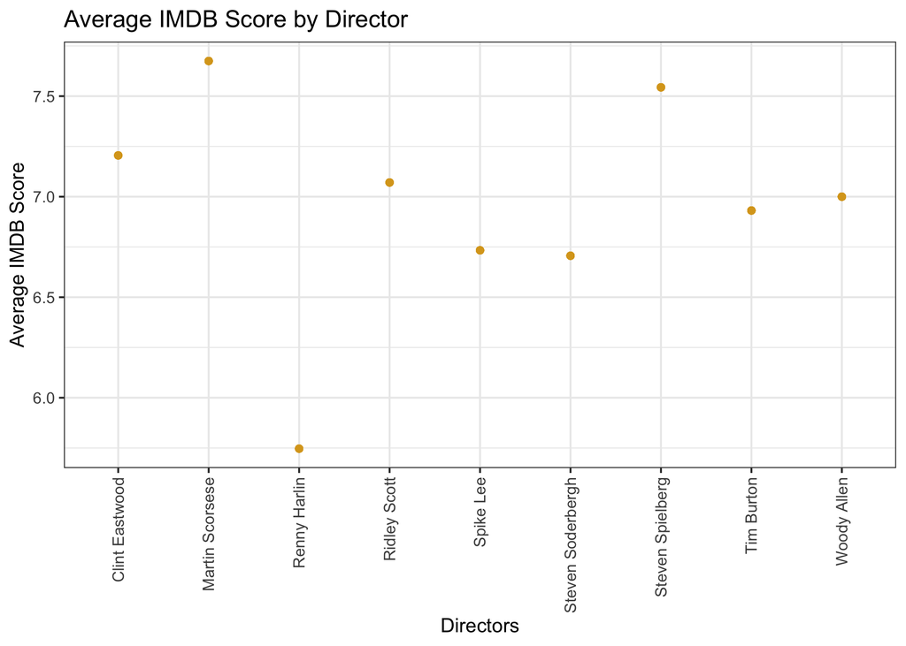

## Top 20 Movies by IMDB Score

```
##    Min. 1st Qu.  Median    Mean 3rd Qu.    Max.
##     1.0   105.0   205.0   330.1   392.8  5060.0
```

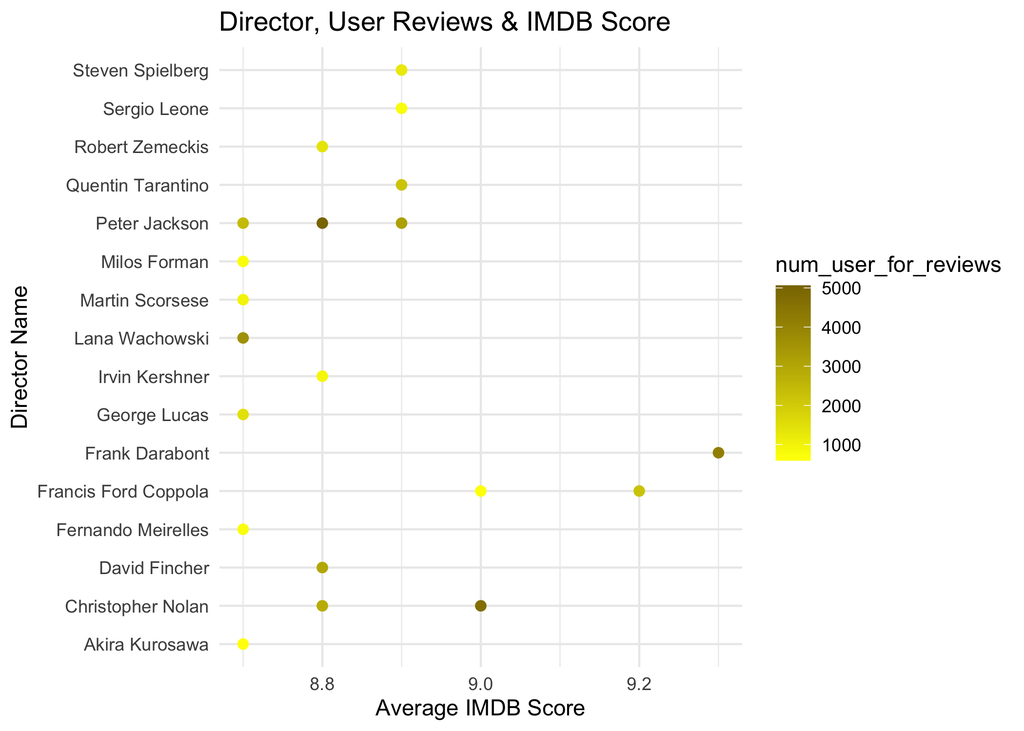

## Impact of Country on the IMDB Score

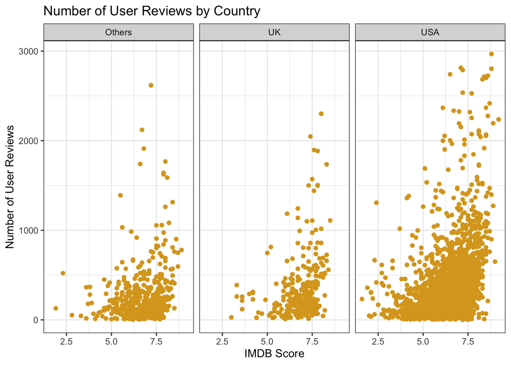

## Movie Durations Impact on the IMDB Score

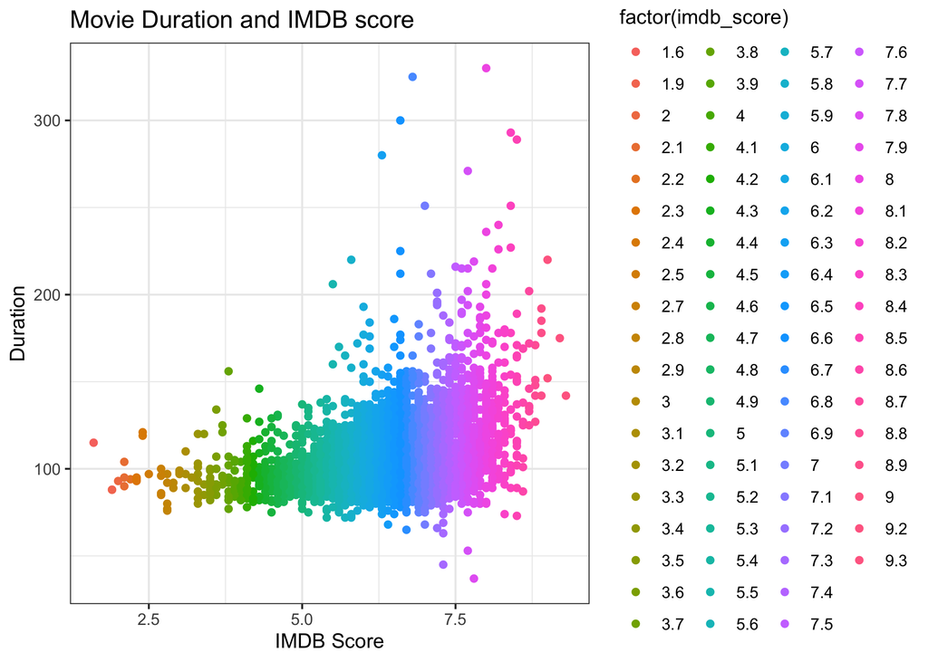

## Impact of Net Profit on IMDB Score.

The trend below shows that higher net profit leads to a high IMDB score. Movies with net profit above $200 million have a higher IMDB score.

Some outliers show a high net profit with low IMDB score. Although, there are movies that have an above average IMDB score but did not generate much profit. Therefore, net profit is not a strong indicator of a high IMDB score.

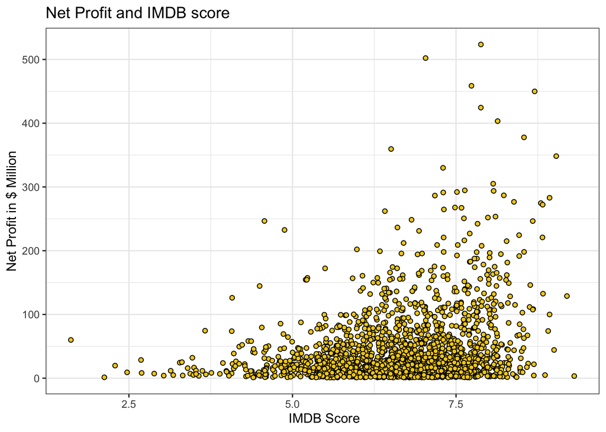

## Advanced Models

We divide the dataset into two parts with 80% of the data as the training data and the rest 20% as the testing data.

## Linear Model

```
##
## Call:
## lm(formula = imdb_score ~ duration + num_voted_users + num_user_for_reviews +
##     budget + gross, data = IMDB_train)
##
## Residuals:
##     Min      1Q  Median      3Q     Max
## -4.7935 -0.4665  0.0768  0.6047  2.4301
##
## Coefficients:
##                        Estimate Std. Error t value Pr(>|t|)
## (Intercept)           4.912e+00  8.549e-02  57.462  < 2e-16 ***
## duration              1.236e-02  8.032e-04  15.387  < 2e-16 ***
## num_voted_users       4.231e-06  1.886e-07  22.432  < 2e-16 ***
## num_user_for_reviews -4.509e-04  6.498e-05  -6.939 4.80e-12 ***
## budget               -1.128e-11  6.595e-11  -0.171    0.864
## gross                -2.049e-09  3.044e-10  -6.733 1.98e-11 ***
## ---
## Signif. codes:  0 '***' 0.001 '**' 0.01 '*' 0.05 '.' 0.1 ' ' 1
##
## Residual standard error: 0.8895 on 3038 degrees of freedom
## Multiple R-squared:  0.2972, Adjusted R-squared:  0.2961
## F-statistic:   257 on 5 and 3038 DF,  p-value: < 2.2e-16
```

## Root Mean Squared Error

Root mean squared error for this linear model is ~ 0.86, which is not considered to be a good predictive model. As the difference between the actual and the prediction is very high.

```
## [1] 0.8593004
```

## Random Forest

```
##      |      Out-of-bag   |
## Tree |      MSE  %Var(y) |
##   50 |   0.5372    47.81 |
##  100 |   0.5194    46.23 |
##  150 |   0.5124    45.60 |
##  200 |   0.5089    45.29 |
##  250 |   0.5053    44.97 |
##  300 |    0.504    44.85 |
##  350 |    0.503    44.76 |
##  400 |   0.5023    44.70 |
##  450 |   0.5025    44.72 |
##  500 |   0.5023    44.70 |
```

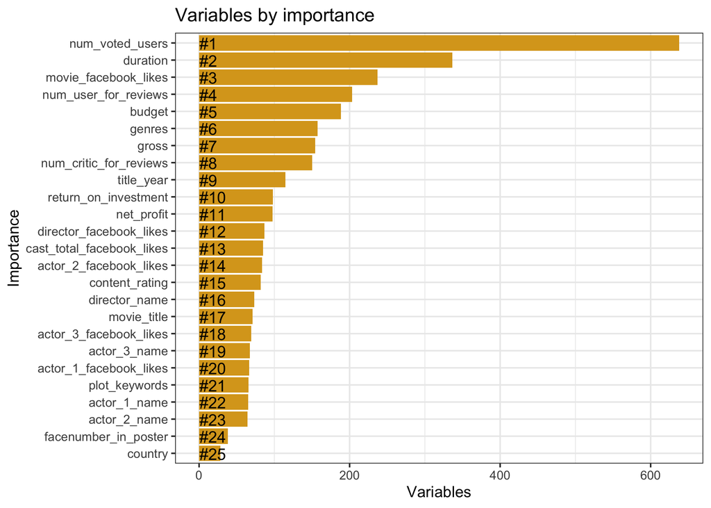

## Root Mean Sqaured Error

```
## [1] 0.6764102
```

## Random Forest with Select Variables

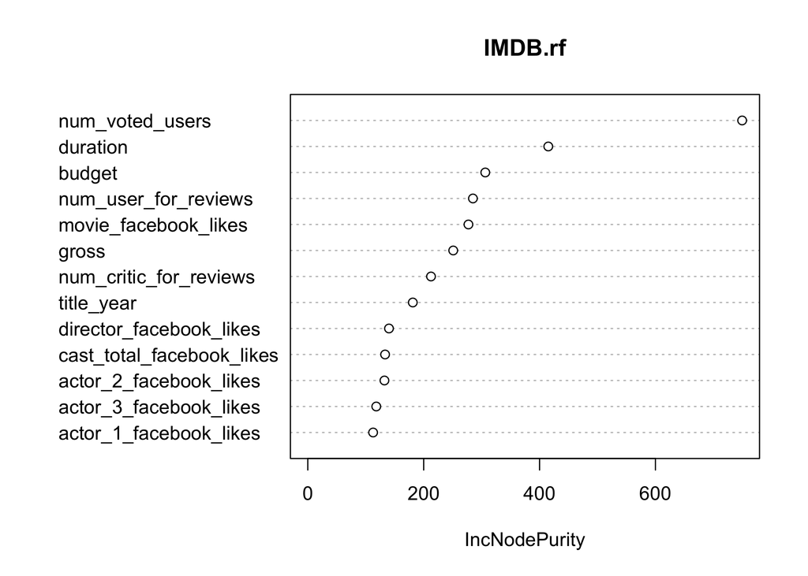

## Root Mean Squared Error

The root mean squared for this model is ~ .67 which is considered to be a good model. The difference between the predicted and the actual values is low.

```
## [1] 0.6593568
```

```
## [1] 0.4347514
```

## Conclusion

The most important variable to affect the IMDB score is the number of voted users. This brings in a new perspective about the movie with every user voting. Some users vote 1/10 for a well highly rated movie. IMDB uses weighted average to reduce the this effect. Collective opinion of a large group of people could be a better representation than a few critics. If a highly rated, awarded movie is rated low on IMDB. It is because the users did not enjoy the movie as much as t was credited.

The third important factor is movies facebook likes as they focused on the users response to the movie. This shows IMDB score heavily relies on the community to review movies. As they want to encapsulate the opinion of a large group to reflect the prevailing thought around the movie.

The importance of next three variables, budget, genres and number of user reviews. High budgeted movies would typically have a tendency to get high IMDB scores because they are heavily promoted. Genres also has an impact because some genres are more popular among users than others. Typically, action and thriller movies are preferred by many viewers.

So, based on the visualizations we can conclude that content rating does not have an impact on the IMDB score. While the IMDB score by countries shows number of movies which has lower IMDB score are the most in the chart. As expected, IMDB score cannot define the profitability of the movies.

Random Forest took into consideration all the variables from the dataset to understand their impact on the IMDB score. Therefore we conclude that number of voted users is the most important variable for a high IMDB score followed by duration and facebook likes received by the audience. It is surprising to see, actors and directors names were among the least important factors as one would think that directors and actors bring in publicity leading to high viewership.